# Task 7

Completed draft: 3 March 17 First upload: 4 March 17

```r
library(tidyverse)
library(dplyr)
library(nycflights13)
```

# Section I

Using nycflights13::weather, determine whether there are any clear outliers in wind speed (wind_speed) that should be rejected. If so, filter those bad point(s) and proceed.

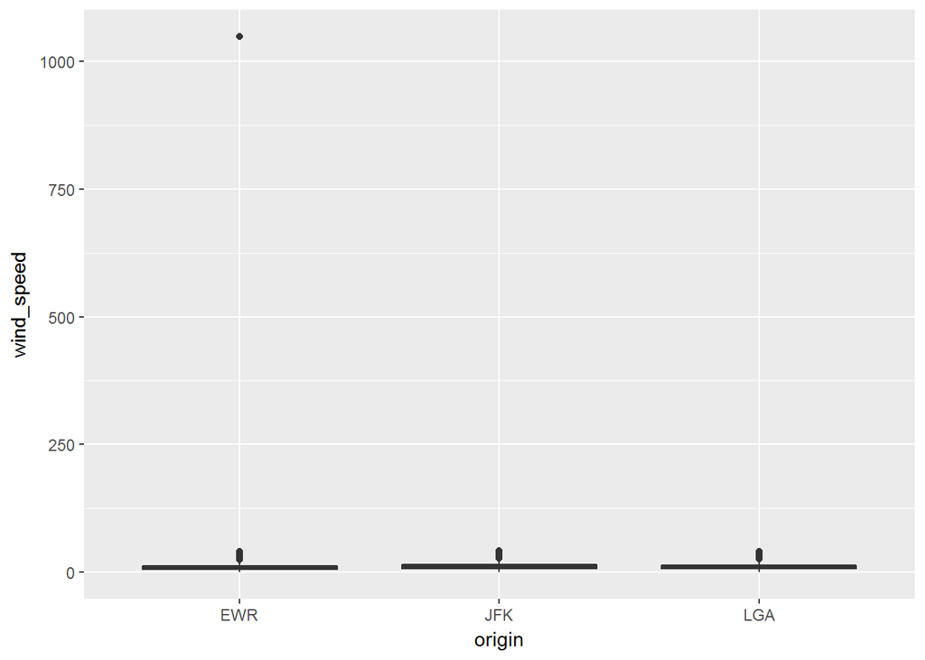

```r
#plot to visiualize outlier
nycflights13::weather %>% ggplot(aes(x = origin, y = wind_speed)) + geom_boxplot()
```

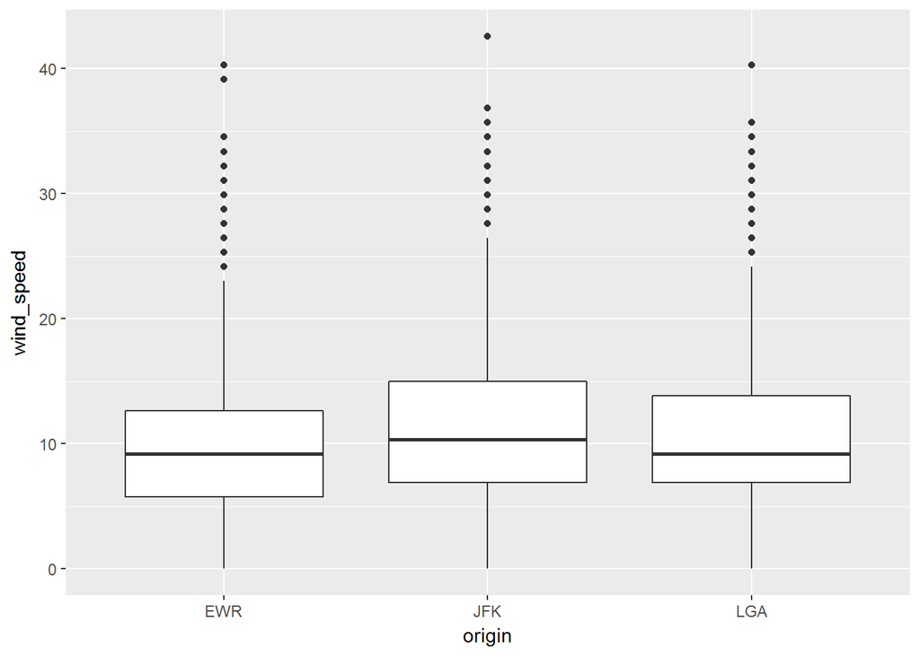

```r
#filter out values we don't want
nycflights <- nycflights13::weather %>% filter(wind_speed < 250.0)

#plotting again to see if additional outliers
nycflights %>% ggplot(aes(x = origin, y = wind_speed)) + geom_boxplot()
```

Make a table and a plot of median wind speed by direction, for each airport. Optional fun challenge: If you like, this is a rare opportunity to make use of coord_polar().

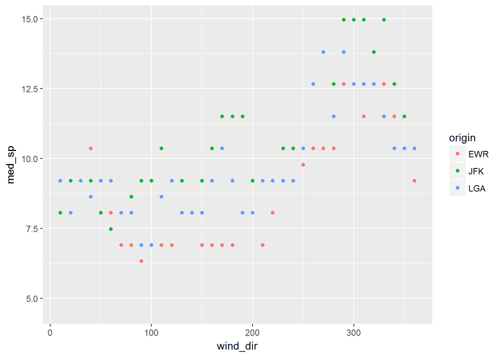

```r
#create new tibble with origin, wind direction, and median wind speed by direction
nycwind <- nycflights %>%
                    group_by(origin, wind_dir) %>%
                    filter(wind_speed > 0) %>%
                    summarise(med_sp = median(wind_speed)) %>%
                    mutate(med_sp) %>%
                    select(origin, wind_dir, med_sp)

#point plot
nycwind %>% ggplot(aes(x = wind_dir, y = med_sp, color = origin)) +
      geom_point()
```

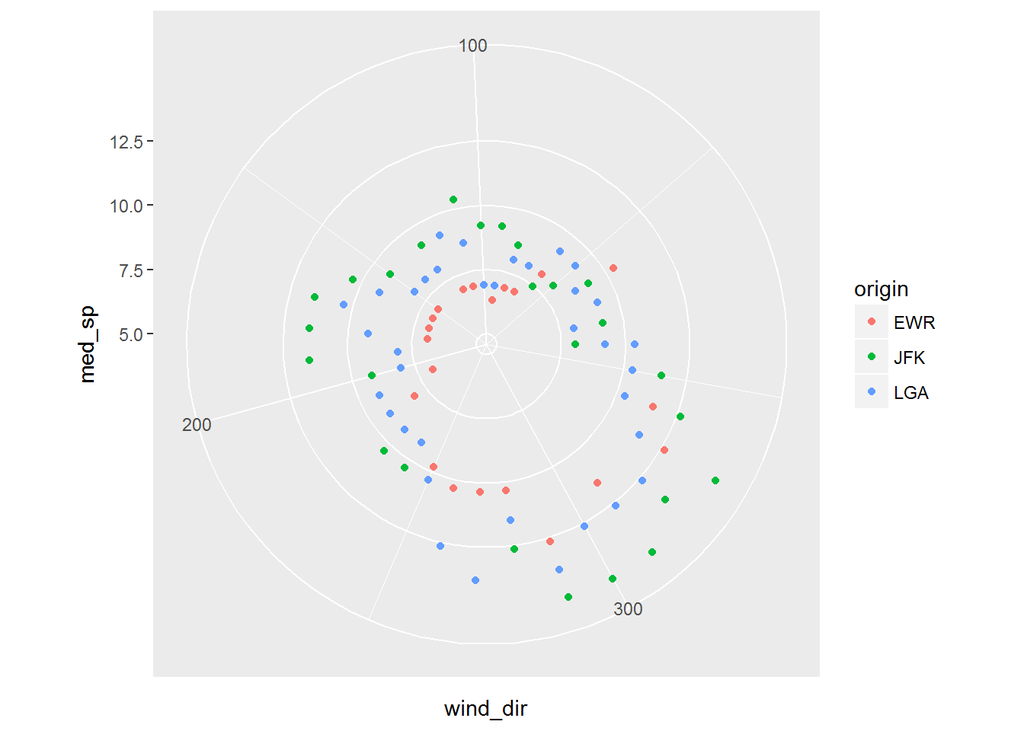

```r
#plot using polar coordinates
nycwind %>% ggplot(aes(x = med_sp, y = wind_dir, color = origin)) +
      geom_point() +
      coord_polar(theta = 'y', start = -pi/2, direction = -1)
```

What direction has the highest median speed at each airport?

```r
#this tibble displays the direction(s) of the max medium wind speeds by airport
max_med_sp <- nycwind %>%
              group_by(origin) %>%
              filter(med_sp == max(med_sp))

max_med_sp
```

```
## Source: local data frame [10 x 3]
## Groups: origin [3]
##
##    origin wind_dir   med_sp
##     <chr>    <dbl>    <dbl>
## 1     EWR      290 12.65858
## 2     EWR      300 12.65858
## 3     EWR      320 12.65858
## 4     EWR      330 12.65858
## 5     JFK      290 14.96014
## 6     JFK      300 14.96014
## 7     JFK      310 14.96014
## 8     JFK      330 14.96014
## 9     LGA      270 13.80936
## 10    LGA      290 13.80936
```

# Section II

Using nycflights13::flights and nycflights13::airlines, make a table with two columns: airline name (not carrier code) and median distance flown from JFK airport. The table should be arranged in order of decreasing mean flight distance. Hint: use a _join function to join flights and airlines.

```r
#visualize the dfs we're starting with
nycflights13::flights
```

```
## # A tibble: 336,776 × 19
##     year month   day dep_time sched_dep_time dep_delay arr_time
##    <int> <int> <int>    <int>          <int>     <dbl>    <int>
## 1   2013     1     1      517            515         2      830
## 2   2013     1     1      533            529         4      850
## 3   2013     1     1      542            540         2      923
## 4   2013     1     1      544            545        -1     1004
## 5   2013     1     1      554            600        -6      812
## 6   2013     1     1      554            558        -4      740
## 7   2013     1     1      555            600        -5      913
## 8   2013     1     1      557            600        -3      709
## 9   2013     1     1      557            600        -3      838
## 10  2013     1     1      558            600        -2      753
## # ... with 336,766 more rows, and 12 more variables: sched_arr_time <int>,
## #   arr_delay <dbl>, carrier <chr>, flight <int>, tailnum <chr>,
## #   origin <chr>, dest <chr>, air_time <dbl>, distance <dbl>, hour <dbl>,
## #   minute <dbl>, time_hour <dttm>
```

```r
nycflights13::airlines
```

```
## # A tibble: 16 × 2
##    carrier                        name
##      <chr>                       <chr>
## 1       9E           Endeavor Air Inc.
## 2       AA      American Airlines Inc.
## 3       AS        Alaska Airlines Inc.
## 4       B6             JetBlue Airways
## 5       DL        Delta Air Lines Inc.
## 6       EV    ExpressJet Airlines Inc.
## 7       F9      Frontier Airlines Inc.
## 8       FL AirTran Airways Corporation
## 9       HA      Hawaiian Airlines Inc.
## 10      MQ                   Envoy Air
## 11      OO       SkyWest Airlines Inc.
## 12      UA       United Air Lines Inc.
## 13      US             US Airways Inc.
## 14      VX              Virgin America
## 15      WN      Southwest Airlines Co.
## 16      YV          Mesa Airlines Inc.
```

```r
#combine the dfs matching carrier with name
airline_dist_jfk <- (nycflights13::flights [,c('carrier', 'distance')] %>%
                    left_join(nycflights13::airlines, by = 'carrier'))[,-1]

#get med, mean and put in descending order
airline_dist_jfk <- airline_dist_jfk %>%
                    group_by(name) %>%
                    summarise(med_dist = median(distance), mean_dist = mean(distance)) %>%
                    arrange(desc(mean_dist))

airline_dist_jfk
```

```
## # A tibble: 16 × 3
##                           name med_dist mean_dist
##                          <chr>    <dbl>     <dbl>
## 1       Hawaiian Airlines Inc.     4983 4983.0000
## 2               Virgin America     2475 2499.4822
## 3         Alaska Airlines Inc.     2402 2402.0000
## 4       Frontier Airlines Inc.     1620 1620.0000
## 5        United Air Lines Inc.     1400 1529.1149
## 6       American Airlines Inc.     1096 1340.2360
## 7         Delta Air Lines Inc.     1020 1236.9012
## 8              JetBlue Airways     1023 1068.6215
## 9       Southwest Airlines Co.      748  996.2691
## 10 AirTran Airways Corporation      762  664.8294
## 11                   Envoy Air      502  569.5327
## 12    ExpressJet Airlines Inc.      533  562.9917
## 13             US Airways Inc.      529  553.4563
## 14           Endeavor Air Inc.      509  530.2358
## 15       SkyWest Airlines Inc.      419  500.8125
## 16          Mesa Airlines Inc.      229  375.0333
```

Make a wide-format data frame that displays the number of flights that leave Newark (“EWR”) airport each month, from each airline

```r
Newark_flights <- nycflights13::flights %>%
                  left_join(nycflights13::airlines, by = 'carrier') %>%    #get carrier name
                  filter(origin == 'EWR') %>%
                  group_by(month, name) %>%
                  summarise(num_flight = length(flight)) %>%    #col length of flight is number of flights
                  spread (month, num_flight)                               #orient horizontally

Newark_flights
```

```
## # A tibble: 12 × 13
##                        name   `1`   `2`   `3`   `4`   `5`   `6`   `7`
## *                     <chr> <int> <int> <int> <int> <int> <int> <int>
## 1      Alaska Airlines Inc.    62    56    62    60    62    60    62
## 2    American Airlines Inc.   298   268   295   288   297   291   303
## 3      Delta Air Lines Inc.   279   249   319   364   377   347   340
## 4         Endeavor Air Inc.    82    75    91    88   103    88    94
## 5                 Envoy Air   212   196   228   220   226   218   228
## 6  ExpressJet Airlines Inc.  3838  3480  3996  3870  4039  3661  3747
## 7           JetBlue Airways   573   532   612   567   517   506   546
## 8     SkyWest Airlines Inc.    NA    NA    NA    NA    NA     2    NA
## 9    Southwest Airlines Co.   529   490   532   518   530   501   526
## 10    United Air Lines Inc.  3657  3433  3913  4025  3874  3931  4046
## 11          US Airways Inc.   363   328   372   361   381   390   402
## 12           Virgin America    NA    NA    NA   170   186   180   181
## # ... with 5 more variables: `8` <int>, `9` <int>, `10` <int>, `11` <int>,
## #   `12` <int>
```

# Section III

Using the babynames dataset, identify the ten most common male and female names in 2014. Make a plot of their frequency (prop) since 1880.

```r
babynames::babynames
```

```
## # A tibble: 1,825,433 × 5
##     year   sex      name     n       prop
##    <dbl> <chr>     <chr> <int>      <dbl>
## 1   1880     F      Mary  7065 0.07238359
## 2   1880     F      Anna  2604 0.02667896
## 3   1880     F      Emma  2003 0.02052149
## 4   1880     F Elizabeth  1939 0.01986579
## 5   1880     F    Minnie  1746 0.01788843
## 6   1880     F  Margaret  1578 0.01616720
## 7   1880     F       Ida  1472 0.01508119
## 8   1880     F     Alice  1414 0.01448696
## 9   1880     F    Bertha  1320 0.01352390
## 10  1880     F     Sarah  1288 0.01319605
## # ... with 1,825,423 more rows
```

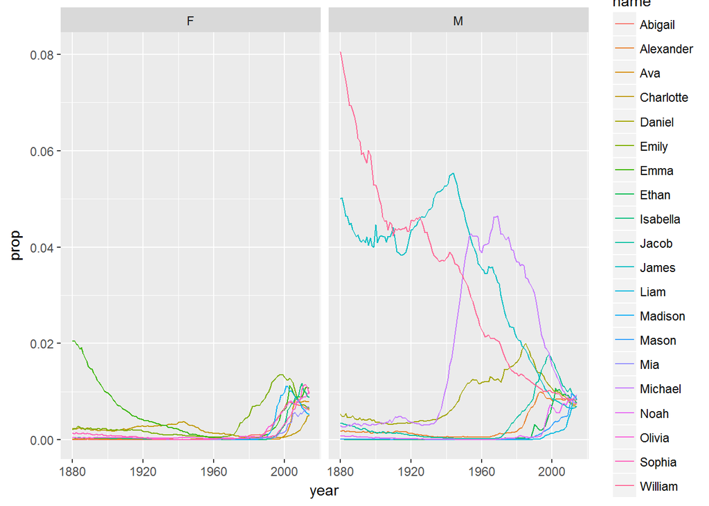

```r
#already in descending order of popularity by year

#new tibble with names from 2014, with top 10 rows for each sex
top_names_14 <- babynames::babynames %>%
                filter(year == 2014) %>%
                group_by(sex) %>%
                top_n(10,n)

#new tiddle with values of names top 10 names for M and F and filter for only those rows in babynames
top_names_freq <- babynames::babynames %>%
                filter(paste0(sex, name) %in% paste0(top_names_14$sex, top_names_14$name))

#plot year,prop, color to distinguish name
top_names_freq %>% ggplot(aes(x = year, y = prop, color = name)) +
                geom_line() +
                facet_grid(.~sex)
```

```r
#there's a short way to do this, but this is mine so far

#tibble of 1896 F names in descending order of popularity
female_1896 <- babynames::babynames %>%
                filter(sex == 'F') %>%
                filter(year == 1896)
#select rows 26-29 correspond to 26th-29th most popular names
female_1896 <- female_1896[26:29,]          #table of 26-29th popular names 1896

female_1942 <- babynames::babynames %>%
                filter(sex == 'F') %>%
                filter(year == 1942)

female_1942 <- female_1942[26:29,]          #table of 26-29th popular names 1942

female_2014 <- babynames::babynames %>%
                filter(sex == 'F') %>%
                filter(year == 2014)

female_2014 <- female_2014[26:29,]          #table of 26-29th popular names 2014

#join the 3 tibbles two at a time
female_26_29 <- full_join(female_1896, female_1942)
female_26_29 <- full_join(female_26_29, female_2014)
female_26_29
```

```
## # A tibble: 12 × 5
##     year   sex     name     n        prop
##    <dbl> <chr>    <chr> <int>       <dbl>
## 1   1896     F   Martha  2022 0.008023969
## 2   1896     F   Esther  1964 0.007793805
## 3   1896     F  Frances  1964 0.007793805
## 4   1896     F    Edith  1932 0.007666819
## 5   1942     F    Helen 10014 0.007202575
## 6   1942     F  Marilyn  9904 0.007123458
## 7   1942     F    Diane  9550 0.006868843
## 8   1942     F   Martha  9513 0.006842231
## 9   2014     F Brooklyn  6767 0.003490782
## 10  2014     F     Lily  6727 0.003470148
## 11  2014     F   Hannah  6512 0.003359240
## 12  2014     F    Layla  6428 0.003315908
```

Section IV

Write task that involves some of the functions on the Data Wrangling Cheat Sheet and execute it. You may either use your own data or data packages (e.g., the ones listed here).

Use the timeseries sunspot.year to visualize and locate peak sunspot activity years.

```r
library(datasets)
library(pastecs)
datasets::sunspot.year
```

```
## Time Series:
## Start = 1700
## End = 1988
## Frequency = 1
##   [1]   5.0  11.0  16.0  23.0  36.0  58.0  29.0  20.0  10.0   8.0   3.0
##  [12]   0.0   0.0   2.0  11.0  27.0  47.0  63.0  60.0  39.0  28.0  26.0
##  [23]  22.0  11.0  21.0  40.0  78.0 122.0 103.0  73.0  47.0  35.0  11.0
##  [34]   5.0  16.0  34.0  70.0  81.0 111.0 101.0  73.0  40.0  20.0  16.0
##  [45]   5.0  11.0  22.0  40.0  60.0  80.9  83.4  47.7  47.8  30.7  12.2
##  [56]   9.6  10.2  32.4  47.6  54.0  62.9  85.9  61.2  45.1  36.4  20.9
##  [67]  11.4  37.8  69.8 106.1 100.8  81.6  66.5  34.8  30.6   7.0  19.8
##  [78]  92.5 154.4 125.9  84.8  68.1  38.5  22.8  10.2  24.1  82.9 132.0
##  [89] 130.9 118.1  89.9  66.6  60.0  46.9  41.0  21.3  16.0   6.4   4.1
## [100]   6.8  14.5  34.0  45.0  43.1  47.5  42.2  28.1  10.1   8.1   2.5
## [111]   0.0   1.4   5.0  12.2  13.9  35.4  45.8  41.1  30.1  23.9  15.6
```

[output cut: 16 more lines]

```r
#build tibble from the ts sunspot.years
sunspot <- data_frame(year = 1700:1988, spots = as_vector(sunspot.year))
tbl_df(sunspot)
```

```
## # A tibble: 289 × 2
##     year spots
##    <int> <dbl>
## 1   1700     5
## 2   1701    11
## 3   1702    16
## 4   1703    23
## 5   1704    36
## 6   1705    58
## 7   1706    29
## 8   1707    20
## 9   1708    10
## 10  1709     8
## # ... with 279 more rows
```

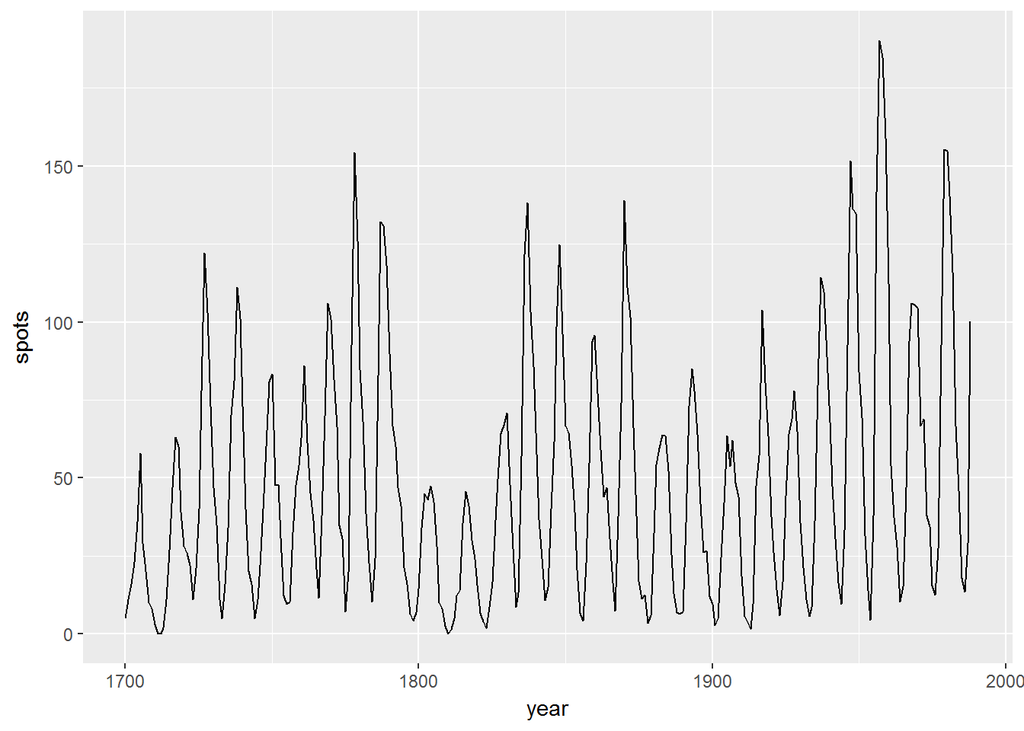

```r
#plot time, activity
sunspot %>% ggplot(aes(x = year, y = spots)) +
                    geom_line()
```

```r
#use pastecs library function turnpoints to find local maxima, minima
e <- turnpoints(sunspot.year)

#create dataframe of peak and year
peaks <- data_frame(peak = as_vector(e$peaks), s = as_vector(e$points))

#the turnpoints function omitted a point when there were 2 consecutive 0's at
#1711 and 1712. Easier to omit a row in sunspots than add one in peaks
sunspot <- sunspot %>% filter(year != 1711)

#combine data into dateframe
cycles <- bind_cols(sunspot, peaks)

#convert to tibble
tbl_df(cycles)
```

```
## # A tibble: 288 × 4
##     year spots  peak     s
##    <int> <dbl> <lgl> <dbl>
## 1   1700     5 FALSE     5
## 2   1701    11 FALSE    11
## 3   1702    16 FALSE    16
## 4   1703    23 FALSE    23
## 5   1704    36 FALSE    36
## 6   1705    58  TRUE    58
## 7   1706    29 FALSE    29
## 8   1707    20 FALSE    20
## 9   1708    10 FALSE    10
## 10  1709     8 FALSE     8
## # ... with 278 more rows
```

```r
maxima <- cycles %>% filter(peak == TRUE) %>%
                    select(year, spots)

#cyclic maximum sunpot activity years
maxima
```

```
## # A tibble: 33 × 2
##     year spots
##    <int> <dbl>
## 1   1705  58.0
## 2   1717  63.0
## 3   1727 122.0
## 4   1738 111.0
## 5   1750  83.4
## 6   1752  47.8
## 7   1761  85.9
## 8   1769 106.1
## 9   1778 154.4
## 10  1787 132.0
## # ... with 23 more rows
```